# CENG 4515 DATA SCIENCE AND ANALYTICS

HOMEWORK - 3

Ayşe Ceren Çiçek

Dataset: Iris Flower Dataset

The columns are:

- Sepal Length: length of the sepal
- Sepal Width: width of the sepal
- Petal Length: length of the petal
- Petal Width: width of the petal
- Species: species name (Setosa, Versicolor, Virginica)

## Importing libraries

```r
#install.packages('caTools')
library(ggplot2)
library(dplyr)
library(factoextra)
library(cluster)
library(caTools)
library(stats)
library(caret)
library(plyr)
```

## Dataset

The dataset is Iris dataset which contains four features (length and width of sepals and petals) of 50 samples of three species of Iris flower (setosa, virginica and versicolor).

```r
data(iris)
summary(iris)
```

```
##   Sepal.Length    Sepal.Width     Petal.Length    Petal.Width
##  Min.   :4.300   Min.   :2.000   Min.   :1.000   Min.   :0.100
##  1st Qu.:5.100   1st Qu.:2.800   1st Qu.:1.600   1st Qu.:0.300
##  Median :5.800   Median :3.000   Median :4.350   Median :1.300
##  Mean   :5.843   Mean   :3.057   Mean   :3.758   Mean   :1.199
##  3rd Qu.:6.400   3rd Qu.:3.300   3rd Qu.:5.100   3rd Qu.:1.800
##  Max.   :7.900   Max.   :4.400   Max.   :6.900   Max.   :2.500
##        Species
##  setosa    :50
##  versicolor:50
##  virginica :50
##
##
##
```

We can visualize the sepal width vs sepal length according to species.

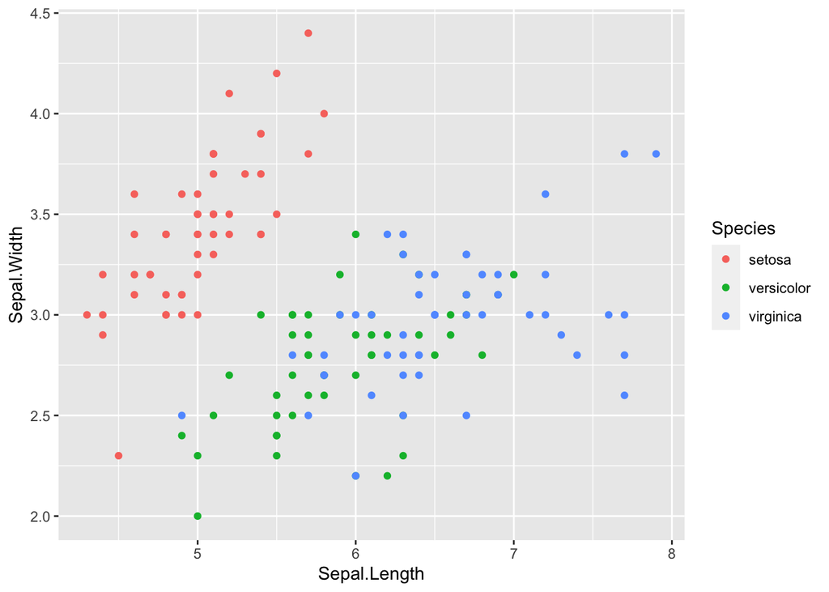

```r
ggplot(data = iris) +
  geom_point(mapping = aes(x = Sepal.Length, y = Sepal.Width, color=Species))
```

As we can see above, the flowers which have longer sepals are mostly from the virginica species. And those which have wider sepals are mostly from the setosa species.

## Apply Principal Component Analysis

PCA is an unsupervised algorithm that is used for dimensionality reduction.

Its goal is to identify and detect the correlation between variables. It is attempting to learn about relationship between values by finding a list of principal axes and it projects high dimensional data into smaller dimensional subspace while keeping most of the information.

Using pca we will try to reduce the dimensionality of this dataset and get new dimensions which represents most of our data. It contains 5 dimensions(4 independent variables). Our dependent variable is Species.

```r
pca <- prcomp(iris[,-5],center = T, scale. = T)
pca
```

```
## Standard deviations (1, .., p=4):
## [1] 1.7083611 0.9560494 0.3830886 0.1439265
##
## Rotation (n x k) = (4 x 4):
##                     PC1         PC2        PC3        PC4
## Sepal.Length  0.5210659 -0.37741762  0.7195664  0.2612863
## Sepal.Width  -0.2693474 -0.92329566 -0.2443818 -0.1235096
## Petal.Length  0.5804131 -0.02449161 -0.1421264 -0.8014492
## Petal.Width   0.5648565 -0.06694199 -0.6342727  0.5235971
```

```r
summary(pca)
```

```
## Importance of components:
##                           PC1    PC2     PC3     PC4
## Standard deviation     1.7084 0.9560 0.38309 0.14393
## Proportion of Variance 0.7296 0.2285 0.03669 0.00518
## Cumulative Proportion  0.7296 0.9581 0.99482 1.00000
```

As seen above, Principle Component 1 (PC1) explains 73% of the total variation in the data set, while PC2 explains 23%. Overall, just PC1 and PC2 can explain 96% of the variance.

Let’s visualize variance of each component.

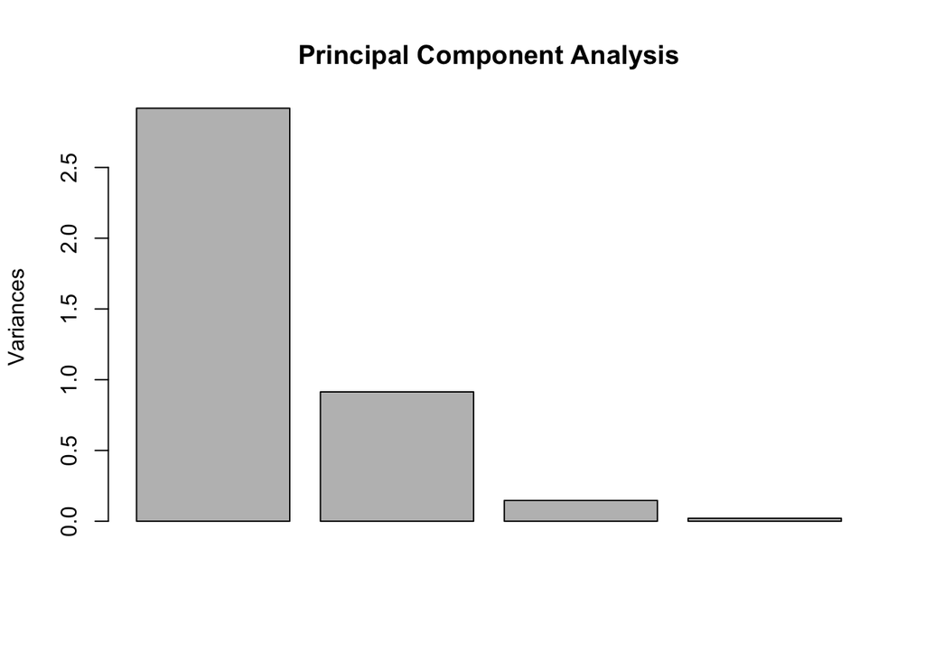

```r
plot(pca, main="Principal Component Analysis")
```

Plot 2-D PCA plot using fviz_pca_ind function.

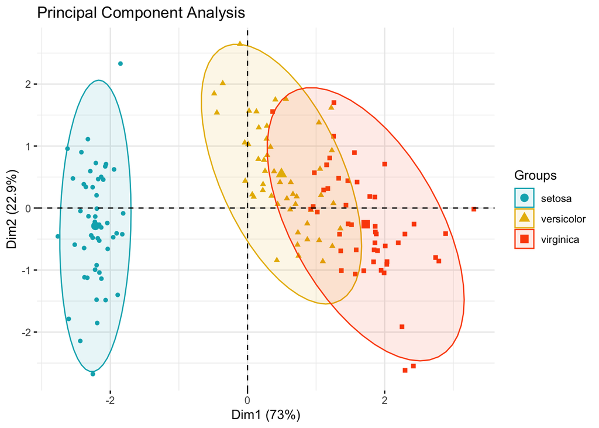

```r
fviz_pca_ind(pca, label = "none", habillage = iris$Species, palette = c("#00AFBB", "#E7B800", "#FC4E07"),
             addEllipses = TRUE) + labs(title = "Principal Component Analysis")
```

PCA is unsupervised learning it does not consider the dependent variable. So we will remove the dependent variable which is the last column Species from our data.

```r
iris_transform = as.data.frame(-pca$x[,1:2])
head(iris_transform, n=5)
```

```
##        PC1        PC2
## 1 2.257141  0.4784238
## 2 2.074013 -0.6718827
## 3 2.356335 -0.3407664
## 4 2.291707 -0.5953999
## 5 2.381863  0.6446757
```

## Elbow method

We are going to use the Elbow Method to decide the optimal number of clusters.

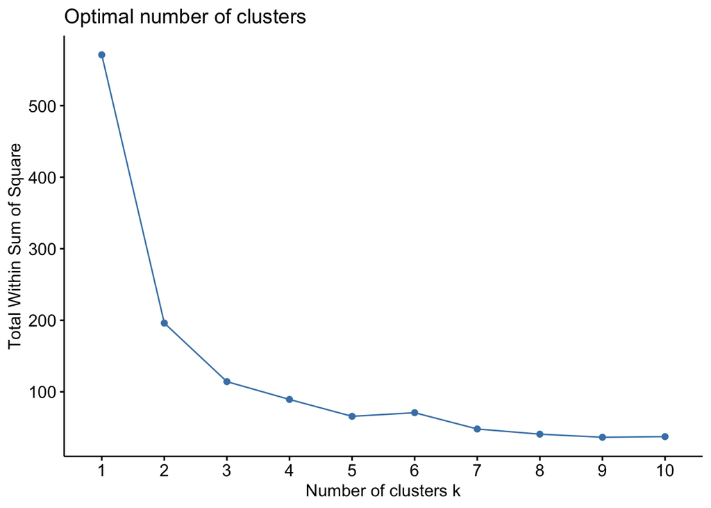

```r
fviz_nbclust(iris_transform, kmeans, method = 'wss')
```

In cluster analysis, the elbow method is used to determine the number of clusters in a data set. The method consists of plotting the explained variation as a function of the number of clusters, and picking the elbow of the curve as the number of clusters to use.

In this data set, we use k =3 because at the value k= 3 there is no significant change in total within sum of square. Now we can apply k-means to cluster the data.

## K-Means Clustering

```r
set.seed(102)
model = kmeans(iris_transform, centers = 3, nstart = 50)
```

Now we have a clustering model which splits our data into 3 clusters.

```r
model
```

```
## K-means clustering with 3 clusters of sizes 47, 50, 53
##
## Cluster means:
##          PC1        PC2
## 1 -1.7152903  0.6008742
## 2  2.2173249  0.2879627
## 3 -0.5707095 -0.8045137
##
## Clustering vector:
##   [1] 2 2 2 2 2 2 2 2 2 2 2 2 2 2 2 2 2 2 2 2 2 2 2 2 2 2 2 2 2 2 2 2 2 2 2 2 2
##  [38] 2 2 2 2 2 2 2 2 2 2 2 2 2 1 1 1 3 3 3 1 3 3 3 3 3 3 3 3 1 3 3 3 3 1 3 3 3
##  [75] 3 1 1 1 3 3 3 3 3 3 3 1 1 3 3 3 3 3 3 3 3 3 3 3 3 3 1 3 1 1 1 1 3 1 1 1 1
## [112] 1 1 3 3 1 1 1 1 3 1 3 1 3 1 1 3 1 1 1 1 1 1 3 3 1 1 1 3 1 1 1 3 1 1 1 3 1
## [149] 1 3
##
## Within cluster sum of squares by cluster:
## [1] 34.82154 44.58037 34.85204
##  (between_SS / total_SS =  80.0 %)
##
## Available components:
##
## [1] "cluster"      "centers"      "totss"        "withinss"     "tot.withinss"
## [6] "betweenss"    "size"         "iter"         "ifault"
```

We can visualize our clusters.

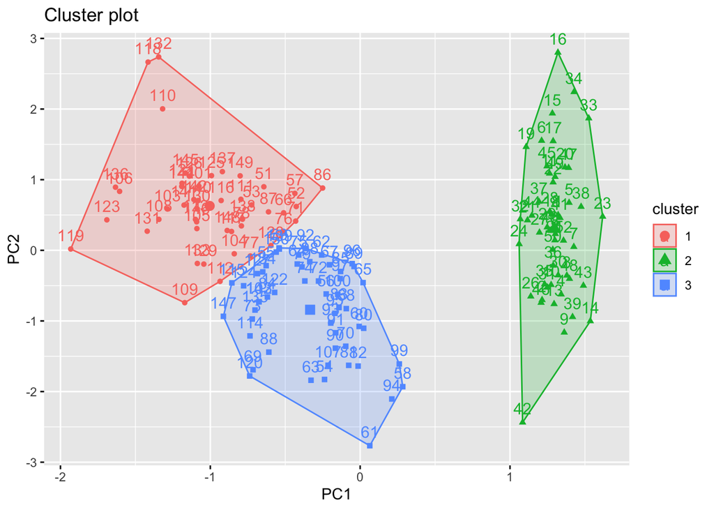

```r
fviz_cluster(model, data = iris_transform)
```

To compose a table for predicted and actual values of the species, we will first store actual species in true.values.

```r
true.values <- iris[5]$Species
true.values
```

```
##   [1] setosa     setosa     setosa     setosa     setosa     setosa
##   [7] setosa     setosa     setosa     setosa     setosa     setosa
##  [13] setosa     setosa     setosa     setosa     setosa     setosa
##  [19] setosa     setosa     setosa     setosa     setosa     setosa
##  [25] setosa     setosa     setosa     setosa     setosa     setosa
##  [31] setosa     setosa     setosa     setosa     setosa     setosa
##  [37] setosa     setosa     setosa     setosa     setosa     setosa
##  [43] setosa     setosa     setosa     setosa     setosa     setosa
##  [49] setosa     setosa     versicolor versicolor versicolor versicolor
##  [55] versicolor versicolor versicolor versicolor versicolor versicolor
##  [61] versicolor versicolor versicolor versicolor versicolor versicolor
##  [67] versicolor versicolor versicolor versicolor versicolor versicolor
##  [73] versicolor versicolor versicolor versicolor versicolor versicolor
##  [79] versicolor versicolor versicolor versicolor versicolor versicolor
##  [85] versicolor versicolor versicolor versicolor versicolor versicolor
##  [91] versicolor versicolor versicolor versicolor versicolor versicolor
##  [97] versicolor versicolor versicolor versicolor virginica  virginica
## [103] virginica  virginica  virginica  virginica  virginica  virginica
## [109] virginica  virginica  virginica  virginica  virginica  virginica
## [115] virginica  virginica  virginica  virginica  virginica  virginica
## [121] virginica  virginica  virginica  virginica  virginica  virginica
## [127] virginica  virginica  virginica  virginica  virginica  virginica
## [133] virginica  virginica  virginica  virginica  virginica  virginica
## [139] virginica  virginica  virginica  virginica  virginica  virginica
## [145] virginica  virginica  virginica  virginica  virginica  virginica
## Levels: setosa versicolor virginica
```

We can reach which cluster each data point belongs to with model$cluster and we can store them in kmeans.predicted value.

```r
kmeans.predicted <- c("versicolor","setosa","virginica")[model$cluster]
kmeans.predicted
```

```
##   [1] "setosa"     "setosa"     "setosa"     "setosa"     "setosa"
##   [6] "setosa"     "setosa"     "setosa"     "setosa"     "setosa"
##  [11] "setosa"     "setosa"     "setosa"     "setosa"     "setosa"
##  [16] "setosa"     "setosa"     "setosa"     "setosa"     "setosa"
##  [21] "setosa"     "setosa"     "setosa"     "setosa"     "setosa"
##  [26] "setosa"     "setosa"     "setosa"     "setosa"     "setosa"
##  [31] "setosa"     "setosa"     "setosa"     "setosa"     "setosa"
##  [36] "setosa"     "setosa"     "setosa"     "setosa"     "setosa"
##  [41] "setosa"     "setosa"     "setosa"     "setosa"     "setosa"
##  [46] "setosa"     "setosa"     "setosa"     "setosa"     "setosa"
##  [51] "versicolor" "versicolor" "versicolor" "virginica"  "virginica"
##  [56] "virginica"  "versicolor" "virginica"  "virginica"  "virginica"
##  [61] "virginica"  "virginica"  "virginica"  "virginica"  "virginica"
##  [66] "versicolor" "virginica"  "virginica"  "virginica"  "virginica"
##  [71] "versicolor" "virginica"  "virginica"  "virginica"  "virginica"
##  [76] "versicolor" "versicolor" "versicolor" "virginica"  "virginica"
##  [81] "virginica"  "virginica"  "virginica"  "virginica"  "virginica"
##  [86] "versicolor" "versicolor" "virginica"  "virginica"  "virginica"
##  [91] "virginica"  "virginica"  "virginica"  "virginica"  "virginica"
##  [96] "virginica"  "virginica"  "virginica"  "virginica"  "virginica"
## [101] "versicolor" "virginica"  "versicolor" "versicolor" "versicolor"
## [106] "versicolor" "virginica"  "versicolor" "versicolor" "versicolor"
## [111] "versicolor" "versicolor" "versicolor" "virginica"  "virginica"
## [116] "versicolor" "versicolor" "versicolor" "versicolor" "virginica"
## [121] "versicolor" "virginica"  "versicolor" "virginica"  "versicolor"
## [126] "versicolor" "virginica"  "versicolor" "versicolor" "versicolor"
## [131] "versicolor" "versicolor" "versicolor" "virginica"  "virginica"
## [136] "versicolor" "versicolor" "versicolor" "virginica"  "versicolor"
## [141] "versicolor" "versicolor" "virginica"  "versicolor" "versicolor"
## [146] "versicolor" "virginica"  "versicolor" "versicolor" "virginica"
```

As the table shows, the model clustered all the setosa species correctly. But it clustered 36 virginica and 39 versicolor wrong.

```r
table(true=true.values,pred=kmeans.predicted)
```

```
##             pred
## true         setosa versicolor virginica
##   setosa         50          0         0
##   versicolor      0         11        39
##   virginica       0         36        14
```

## Agglomerative Hierarchical Clustering

First we will compute dissimilarity matrix with dist function using euclidean distance.

```r
# Dissimilarity matrix
d <- dist(iris_transform, method = "euclidean")
```

Now we can feed these values into our hierarchical clustering model.

```r
hc <- hclust(d, method = "average" )
```

We will plot the dendogram as seen below.

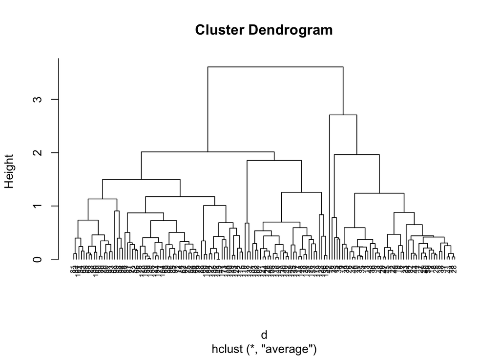

```r
plot(hc, cex = 0.6, hang = -1)
```

Using cutree function we will cut the dendrogram from height 3. Also, we will assign the actual values of the species to compare easily with actual values.

```r
hc <- c("setosa","versicolor","virginica")[cutree(hc, h = 3)]
hc
```

```
##   [1] "setosa"     "setosa"     "setosa"     "setosa"     "setosa"
##   [6] "setosa"     "setosa"     "setosa"     "setosa"     "setosa"
##  [11] "setosa"     "setosa"     "setosa"     "setosa"     "setosa"
##  [16] "setosa"     "setosa"     "setosa"     "setosa"     "setosa"
##  [21] "setosa"     "setosa"     "setosa"     "setosa"     "setosa"
##  [26] "setosa"     "setosa"     "setosa"     "setosa"     "setosa"
##  [31] "setosa"     "setosa"     "setosa"     "setosa"     "setosa"
##  [36] "setosa"     "setosa"     "setosa"     "setosa"     "setosa"
##  [41] "setosa"     "setosa"     "setosa"     "setosa"     "setosa"
##  [46] "setosa"     "setosa"     "setosa"     "setosa"     "setosa"
##  [51] "versicolor" "versicolor" "versicolor" "versicolor" "versicolor"
##  [56] "versicolor" "versicolor" "versicolor" "versicolor" "versicolor"
##  [61] "versicolor" "versicolor" "versicolor" "versicolor" "versicolor"
##  [66] "versicolor" "versicolor" "versicolor" "versicolor" "versicolor"
##  [71] "versicolor" "versicolor" "versicolor" "versicolor" "versicolor"
##  [76] "versicolor" "versicolor" "versicolor" "versicolor" "versicolor"
##  [81] "versicolor" "versicolor" "versicolor" "versicolor" "versicolor"
##  [86] "versicolor" "versicolor" "versicolor" "versicolor" "versicolor"
##  [91] "versicolor" "versicolor" "versicolor" "versicolor" "versicolor"
##  [96] "versicolor" "versicolor" "versicolor" "versicolor" "versicolor"
## [101] "versicolor" "versicolor" "versicolor" "versicolor" "versicolor"
## [106] "versicolor" "versicolor" "versicolor" "versicolor" "versicolor"
## [111] "versicolor" "versicolor" "versicolor" "versicolor" "versicolor"
## [116] "versicolor" "versicolor" "versicolor" "versicolor" "versicolor"
## [121] "versicolor" "versicolor" "versicolor" "versicolor" "versicolor"
## [126] "versicolor" "versicolor" "versicolor" "versicolor" "versicolor"
## [131] "versicolor" "versicolor" "versicolor" "versicolor" "versicolor"
## [136] "versicolor" "versicolor" "versicolor" "versicolor" "versicolor"
## [141] "versicolor" "versicolor" "versicolor" "versicolor" "versicolor"
## [146] "versicolor" "versicolor" "versicolor" "versicolor" "versicolor"
```

```r
iris_transform %>%
  mutate(cluster = hc) %>%
  head
```

```
##        PC1        PC2 cluster
## 1 2.257141  0.4784238  setosa
## 2 2.074013 -0.6718827  setosa
## 3 2.356335 -0.3407664  setosa
## 4 2.291707 -0.5953999  setosa
## 5 2.381863  0.6446757  setosa
## 6 2.068701  1.4842053  setosa
```

The table down below shows the actual and the predicted values of the species. According to it, the model clustered setosa and versicolor species as their actual classes but it did not cluster any of the data points of the virginica species with their correct class.

```r
table <- table(true=true.values,pred=hc)
table
```

```
##             pred
## true         setosa versicolor
##   setosa         50          0
##   versicolor      0         50
##   virginica       0         50
```